# Introduction to R - part 2

Author: Aurélie Labbe, translation: Juliana Schulz

**Before starting, make sure that you have downloaded all necessary files (pdf, html, R code, data) and that they are saved in an appropriate directory on your computer. Also make sure that the code `IntroR_part2_en.R` is open in the RStudio editor. Finally, you should be comfortable with the concepts covered in the first part of the introduction to R before starting this session.**

In this document, we will cover the following concepts:

- Descriptive statistics
- Graphs

## Datasets used

### Electricity data

We’ll illustrate the use of different concepts and commands in R using a dataset on household electricity consumption between January 1991 and December 2000. Each line of the dataset represents information for one given month. The data are saved in the `electricbill.txt` and `electricbill.csv` files. The dataset includes the following variables:

- `NUM`: identification of the observation
- `YEAR`: year
- `MONTH`: month
- `BILL`: bill amount, in dollars (including 5% sale tax)
- `TEMP`: mean temperature (in Fahrenheit)
- `HDD`: measure quantifying the amount of energy necessary to heat the building
- `CDD`: measure quantifying the amount of energy necessary to cool the building
- `SIZE`: number of people living in the house
- `METER`: presence of a new electrical meter (1=yes, 0=no)
- `PUMP1`: presence of a new heat pump (1=yes, 0=no)
- `PUMP2`: presence of a new heat pump for the second time (1=yes, 0=no)
- `RIDER TOTAL`: total load (by kwh)
- `CONSUMPTION`: consumption (in kwh)

### Baby-boom data

You will practice the concepts learned using the `babyboom.txt` dataset. The data contains information on the time of birth, sex and birth weight of 44 babies born in a 24 hour period at the Brisbane Hospital, Australia. The variables are as follows:

- `Time`: time of birth
- `Sex`: baby’s sex (1=female, 2=male)
- `Weight`: baby’s birthweight (in grams)
- `Time.midnight`: number of minutes past midnight at the moment of birth

## Descriptive statistics and pre-defined functions in R

The following chunk of code illustrates some of the pre-defined functions available in R, which are applicable to vectors (e.g., for the columns of a dataset):

```r
# Read dataset
mydata=read.table("Data/electricbill.txt", header=TRUE)
mydata2=data.frame(YEAR=mydata$YEAR, MONTH=mydata$MONTH,
                   BILL=mydata$BILL, CONSUMPTION=mydata$CONSUMPTION)
attach(mydata2)

length(BILL)
```

```
## [1] 120
```

```r
sum(BILL)
```

```
## [1] 12112.63
```

```r
sum(BILL^2)
```

```
## [1] 1539580
```

```r
mean(BILL)
```

```
## [1] 100.9386
```

```r
var(BILL)
```

```
## [1] 2663.434
```

```r
sd(BILL)
```

```
## [1] 51.60847
```

```r
sqrt(var(BILL))
```

```
## [1] 51.60847
```

```r
summary(BILL)
```

```
##    Min. 1st Qu.  Median    Mean 3rd Qu.    Max.
##    0.00   69.67   86.16  100.94  127.64  256.90
```

```r
summary(BILL^2)
```

```
##    Min. 1st Qu.  Median    Mean 3rd Qu.    Max.
##       0    4855    7423   12830   16293   65998
```

```r
quantile(BILL,0.25)
```

```
##    25%
## 69.675
```

```r
table(YEAR)
```

[output not shown]

We can also apply some functions to a dataframe object:

```r
summary(mydata2)
```

```
##       YEAR         MONTH                BILL         CONSUMPTION
##  Min.   :1991   Length:120         Min.   :  0.00   Min.   :  264
##  1st Qu.:1993   Class :character   1st Qu.: 69.67   1st Qu.: 1796
##  Median :1996   Mode  :character   Median : 86.16   Median : 2602
##  Mean   :1996                      Mean   :100.94   Mean   : 3372
##  3rd Qu.:1998                      3rd Qu.:127.64   3rd Qu.: 4500
##  Max.   :2000                      Max.   :256.90   Max.   :13784
```

```r
nrow(mydata2)
```

```
## [1] 120
```

```r
ncol(mydata2)
```

```
## [1] 4
```

```r
dim(mydata2)
```

```
## [1] 120   4
```

Note that the R documentation is very well done and very helpful. To obtain help for a specific function (e.g., `mean`), simply type the command `help(mean)` or `?mean` in the Console and the help file will be displayed in the bottom right screen in RStudio.

There also exists numerous functions that are specific to certain libraries in R. To use these functions, the library must already be installed and loaded. For example, the function `mvrnorm`, which allows to generate variables from the multivariate normal distribution, is available in the `MASS` library (i.e., it is not part of the base functions available in R). Once you have installed the package, this library will be a permenant part of the libraries available to you in R. Note that in order to use the functionalities of a given library, you must first load the library in your work session in R. For example:

```r
# Load library
library(MASS)
# generate a random sample from the multivariate normal distribution
x=mvrnorm(100,mu=1,Sigma=1)
```

## Data extraction

When analyzing data, it’s often required to extract a sub-sample of the data in order to carry out specific analyses (e.g., we want to extract females who have been working for over 10 years). We have already seen how to extract a specific row/column of a dataframe using the `[]` brackets. We’ll now see how this can be combined with logical conditions (`TRUE` / `FALSE`).

We’ll begin by seeing how to create a logical type variable, based on a specific condition. In the following example, the variable `condition` takes the value `TRUE` if the condition `YEAR=1991` is true (CAREFUL, a condition “=” is coded as `==` in R):

```r
condition=(YEAR==1991)
condition
```

```
##   [1]  TRUE  TRUE  TRUE  TRUE  TRUE  TRUE  TRUE  TRUE  TRUE  TRUE  TRUE  TRUE
##  [13] FALSE FALSE FALSE FALSE FALSE FALSE FALSE FALSE FALSE FALSE FALSE FALSE
##  [25] FALSE FALSE FALSE FALSE FALSE FALSE FALSE FALSE FALSE FALSE FALSE FALSE
##  [37] FALSE FALSE FALSE FALSE FALSE FALSE FALSE FALSE FALSE FALSE FALSE FALSE
##  [49] FALSE FALSE FALSE FALSE FALSE FALSE FALSE FALSE FALSE FALSE FALSE FALSE
##  [61] FALSE FALSE FALSE FALSE FALSE FALSE FALSE FALSE FALSE FALSE FALSE FALSE
##  [73] FALSE FALSE FALSE FALSE FALSE FALSE FALSE FALSE FALSE FALSE FALSE FALSE
##  [85] FALSE FALSE FALSE FALSE FALSE FALSE FALSE FALSE FALSE FALSE FALSE FALSE
##  [97] FALSE FALSE FALSE FALSE FALSE FALSE FALSE FALSE FALSE FALSE FALSE FALSE
## [109] FALSE FALSE FALSE FALSE FALSE FALSE FALSE FALSE FALSE FALSE FALSE FALSE
```

We can also consider other logical operators as well:

```r
condition=(YEAR>1995) # year greater than 1995
condition=(YEAR>=1995) # year greater than or equal to 1995
condition=(YEAR!=1992) # year different from 1992
```

We can extract elements from a vector according to a specific condition using the extraction symbol, i.e., `[]`, as illustrated below:

```r
# Extract the elements of the variable YEAR for which the condition holds true
condition=(YEAR>1995)
YEAR[condition]
```

```
##  [1] 1996 1996 1996 1996 1996 1996 1996 1996 1996 1996 1996 1996 1997 1997 1997
## [16] 1997 1997 1997 1997 1997 1997 1997 1997 1997 1998 1998 1998 1998 1998 1998
## [31] 1998 1998 1998 1998 1998 1998 1999 1999 1999 1999 1999 1999 1999 1999 1999
## [46] 1999 1999 1999 2000 2000 2000 2000 2000 2000 2000 2000 2000 2000 2000 2000
```

```r
# An equivalent (and more direct way) to do this:
YEAR[YEAR>1995]
```

```
##  [1] 1996 1996 1996 1996 1996 1996 1996 1996 1996 1996 1996 1996 1997 1997 1997
## [16] 1997 1997 1997 1997 1997 1997 1997 1997 1997 1998 1998 1998 1998 1998 1998
## [31] 1998 1998 1998 1998 1998 1998 1999 1999 1999 1999 1999 1999 1999 1999 1999
## [46] 1999 1999 1999 2000 2000 2000 2000 2000 2000 2000 2000 2000 2000 2000 2000
```

```r
# Extract elements from the BILL variable corresponding to the year 1991
BILL[YEAR==1991]
```

```
##  [1] 162.10 256.90 151.15 118.76 100.71  83.97  99.40 103.64  71.59  94.92
## [11]  78.83 182.85
```

In a similar mananer, we can extract values from a matrix or a dataframe by specifying specific conditions. Here are some examples:

```r
# Extract observations from the mydata2 dataset corresponding to the year 1991
mydata2[YEAR==1991,]
```

```
##    YEAR MONTH   BILL CONSUMPTION
## 1  1991   Jan 162.10        5600
## 2  1991   Feb 256.90        9463
## 3  1991   Mar 151.15        5154
## 4  1991   Apr 118.76        3576
## 5  1991   May 100.71        2894
## 6  1991   Jun  83.97        2257
## 7  1991   Jul  99.40        2826
## 8  1991   Aug 103.64        2986
## 9  1991   Sep  71.59        1774
## 10 1991   Oct  94.92        2713
## 11 1991   Nov  78.83        2092
## 12 1991   Dec 182.85        6109
```

```r
# Extract observations from the mydata2 dataset with BILL>200
mydata2[BILL>200,]
```

```
##    YEAR MONTH   BILL CONSUMPTION
## 2  1991   Feb 256.90        9463
## 26 1993   Feb 222.99        7864
## 27 1993   Mar 214.45        7526
## 61 1996   Jan 218.67       11644
## 62 1996   Feb 256.02       13784
## 63 1996   Mar 222.21       12544
```

We can also combine several logical operations together using the `&` (AND) operator, or using the `|` (OR) operator. Here are some examples:

```r
# Create a new dataframe containing only observations for the months of january and february
mydata4=mydata[(MONTH=='Jan' |MONTH=='Feb') ,]
dim(mydata4)
```

```
## [1] 20 13
```

```r
head(mydata4)
```

```
##    NUM YEAR MONTH   BILL TEMP  HDD CDD SIZE METER PUMP1 PUMP2     RIDER
## 1    1 1991   Jan 162.10 29.1 1229   0    4     0     0     0 -0.002288
## 2    2 1991   Feb 256.90 31.5  999   0    4     0     0     0 -0.002288
## 13  13 1992   Jan 165.23 29.1 1229   0    4     0     0     0 -0.000870
## 14  14 1992   Feb 197.94 31.5  999   0    4     0     0     0 -0.000870
## 25  25 1993   Jan 180.08 29.1 1229   0    4     0     0     0 -0.001643
## 26  26 1993   Feb 222.99 31.5  999   0    4     0     0     0 -0.001643
##    CONSUMPTION
## 1         5600
## 2         9463
## 13        5400
## 14        6657
## 25        6163
## 26        7864
```

```r
# Create a new dataframe containing only observations with 100<BILL<200
mydata4=mydata[(BILL>100  & BILL<200) ,]
dim(mydata4)
```

```
## [1] 41 13
```

```r
head(mydata4)
```

```
##    NUM YEAR MONTH   BILL TEMP  HDD CDD SIZE METER PUMP1 PUMP2     RIDER
## 1    1 1991   Jan 162.10 29.1 1229   0    4     0     0     0 -0.002288
## 3    3 1991   Mar 151.15 41.9  734   0    4     0     0     0 -0.002288
## 4    4 1991   Apr 118.76 53.4  373   0    4     0     0     0 -0.000600
## 5    5 1991   May 100.71 63.7  162  94    4     0     0     0 -0.000634
## 8    8 1991   Aug 103.64 75.0    0 261    4     0     0     0 -0.000473
## 12  12 1991   Dec 182.85 32.5 1049   0    4     0     0     0 -0.001002
##    CONSUMPTION
## 1         5600
## 3         5154
## 4         3576
## 5         2894
## 8         2986
## 12        6109
```

**Exercise**: Create a new dataframe called `mydata.winter` which contains only observations for the months of Dec-Jan-Feb for which `BILL>100`. For this new dataset, calculate the mean, minimum and maximum values for the `BILL` variable. Using the `cor` function, calculate the correlation between the variales `BILL` and `CONSUMPTION`.

To finish, we’ll see how to extract data based on a sequence of IDs that we want to examine (e.g., extract the first 10 rows of a dataset). First, the following examples show how to create a sequence of numbers (IDs) in R:

```r
# Sequence from 1 to 10
z=1:10
z
```

```
##  [1]  1  2  3  4  5  6  7  8  9 10
```

```r
# Sequence form 5 to 10
z=5:10
z
```

```
## [1]  5  6  7  8  9 10
```

```r
# Sequence from 1 to 10 with jumps of 2
w=seq(from=1,to=10,by=2)
w
```

```
## [1] 1 3 5 7 9
```

```r
# Sequence from 0 to 10 (of length 11)
w=seq(0,10,length=11)
w
```

```
##  [1]  0  1  2  3  4  5  6  7  8  9 10
```

```r
# Repetition of the number 1, repeated 10 times
w=rep(1,10)
w
```

```
##  [1] 1 1 1 1 1 1 1 1 1 1
```

```r
# Repetition of the sequence 1-2-3, repeated 5 times
w=rep(1:3,5)
w
```

```
##  [1] 1 2 3 1 2 3 1 2 3 1 2 3 1 2 3
```

```r
# Repetition of another sequence, repeated 2 times
w=rep(seq(from=1,to=10,by=2),2)
w
```

```
##  [1] 1 3 5 7 9 1 3 5 7 9
```

Using the same logic we previously explored, it is possible to extract elements from a dataframe, a vector, or a matrix, by specifying a sequence of observations. Here are some examples:

```r
# Extract observations 1,3, and 6 from BILL
BILL[c(1,3,6)]
```

```
## [1] 162.10 151.15  83.97
```

```r
# Extract  the first 10 observations from BILL
BILL[1:10]
```

```
##  [1] 162.10 256.90 151.15 118.76 100.71  83.97  99.40 103.64  71.59  94.92
```

```r
# Extract the first 10 lines from mydata
mydata2[1:10,]
```

```
##    YEAR MONTH   BILL CONSUMPTION
## 1  1991   Jan 162.10        5600
## 2  1991   Feb 256.90        9463
## 3  1991   Mar 151.15        5154
## 4  1991   Apr 118.76        3576
## 5  1991   May 100.71        2894
## 6  1991   Jun  83.97        2257
## 7  1991   Jul  99.40        2826
## 8  1991   Aug 103.64        2986
## 9  1991   Sep  71.59        1774
## 10 1991   Oct  94.92        2713
```

```r
# Extract every second row from mydata2 for columns (1,2,4)
mydata2[seq(1,nrow(mydata),by=2),c(1,2,4)]
```

```
##     YEAR MONTH CONSUMPTION
## 1   1991   Jan        5600
## 3   1991   Mar        5154
## 5   1991   May        2894
## 7   1991   Jul        2826
## 9   1991   Sep        1774
## 11  1991   Nov        2092
## 13  1992   Jan        5400
## 15  1992   Mar        4692
## 17  1992   May        3631
## 19  1992   Jul        1905
## 21  1992   Sep        1800
## 23  1992   Nov        2040
## 25  1993   Jan        6163
## 27  1993   Mar        7526
```

[output cut: 46 more lines]

## Graphs

R can produce a wide variety of high quality graphs in various formats (wmf, ps, jpg, pdf, png, bmp). There are R libraries such as `ggplot` and `ggplot2` that allow you to create graphics and figures of exceptional quality. The syntax of these functions is not necessarily obvious to a beginner in R, and we will not go into detail here.

Here is basic code for using the `plot` function in R; this allows to create a simple scatterplot:

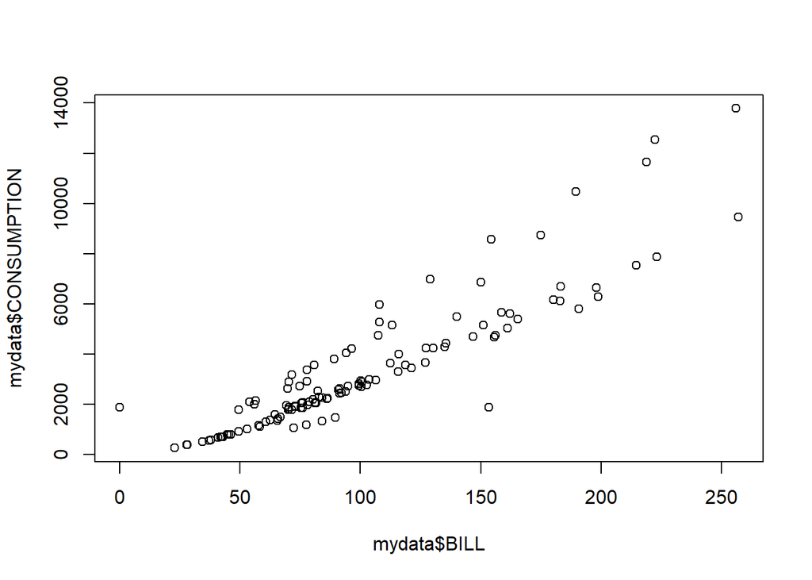

```r
plot(mydata$BILL,mydata$CONSUMPTION)
```

We can easily add a title to the graph, and label the axes:

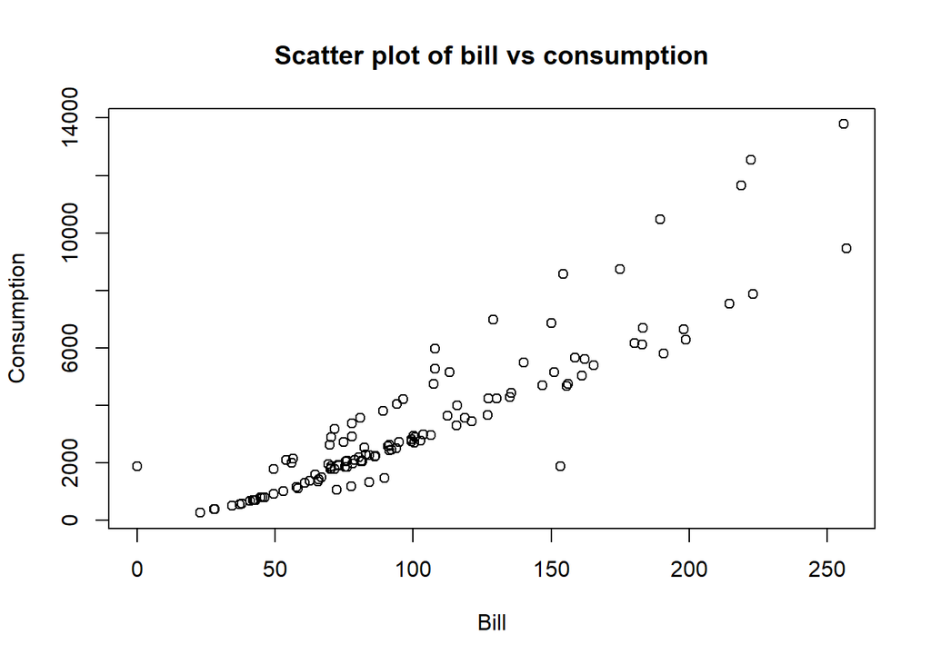

```r
plot(mydata$BILL,mydata$CONSUMPTION, main="Scatter plot of bill vs consumption",
     xlab="Bill", ylab="Consumption")
```

We can also add color and use different symbols for the points…

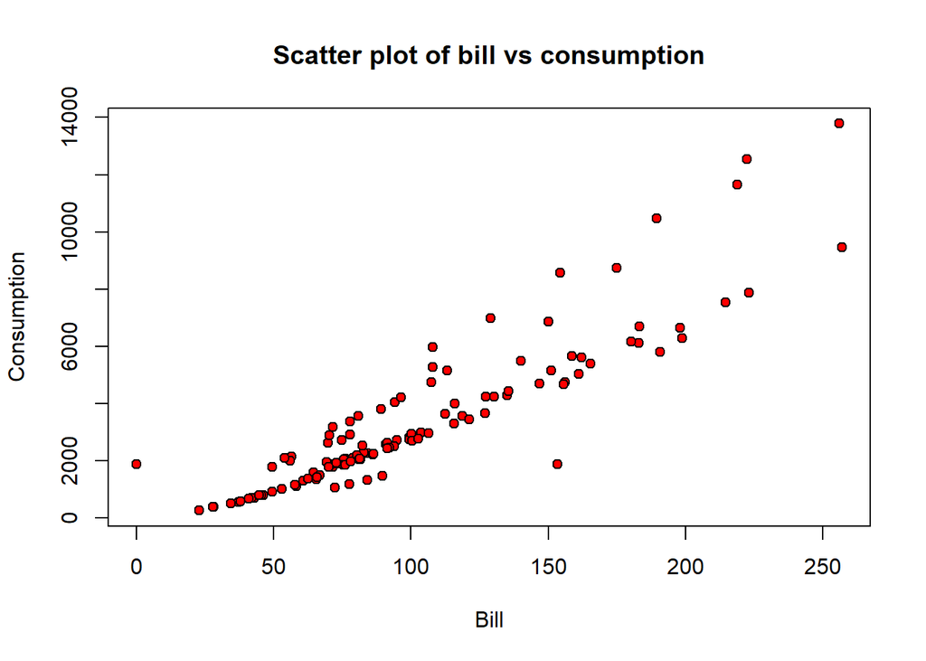

```r
plot(mydata$BILL,mydata$CONSUMPTION, main="Scatter plot of bill vs consumption",
     xlab="Bill", ylab="Consumption",pch=21, bg="red")
```

The following code shows how to add the best fitting line passing through the points, as well as vertical and horizontal lines:

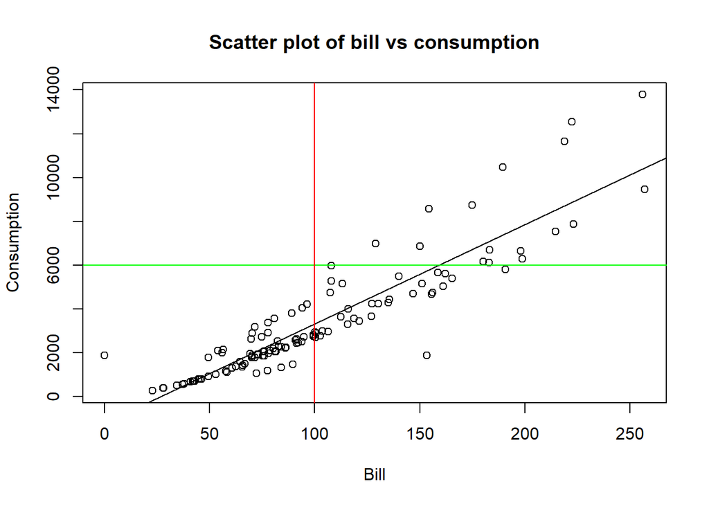

```r
plot(mydata$BILL,mydata$CONSUMPTION, main="Scatter plot of bill vs consumption",
        xlab="Bill", ylab="Consumption")
regress=lm(mydata$CONSUMPTION~mydata$BILL)
abline(regress)
abline(h=6000, col="green")
abline(v=100, col="red")
```

Here is another example, where the points on the graph are connected by a line thereby allowing to visualize the trend or trajectory:

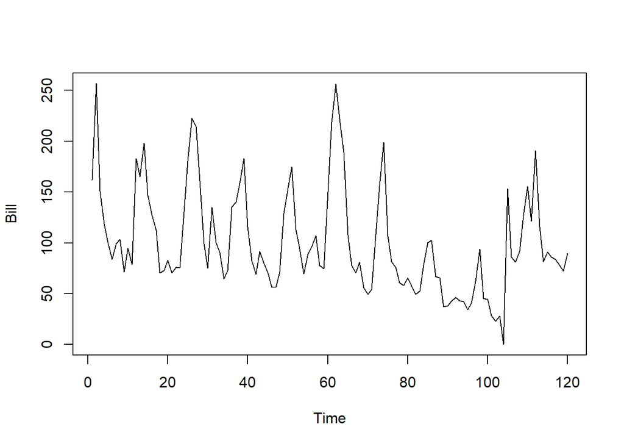

```r
plot(mydata$NUM,mydata$BILL,type="l",xlab="Time",ylab="Bill")
```

We can also produce histograms:

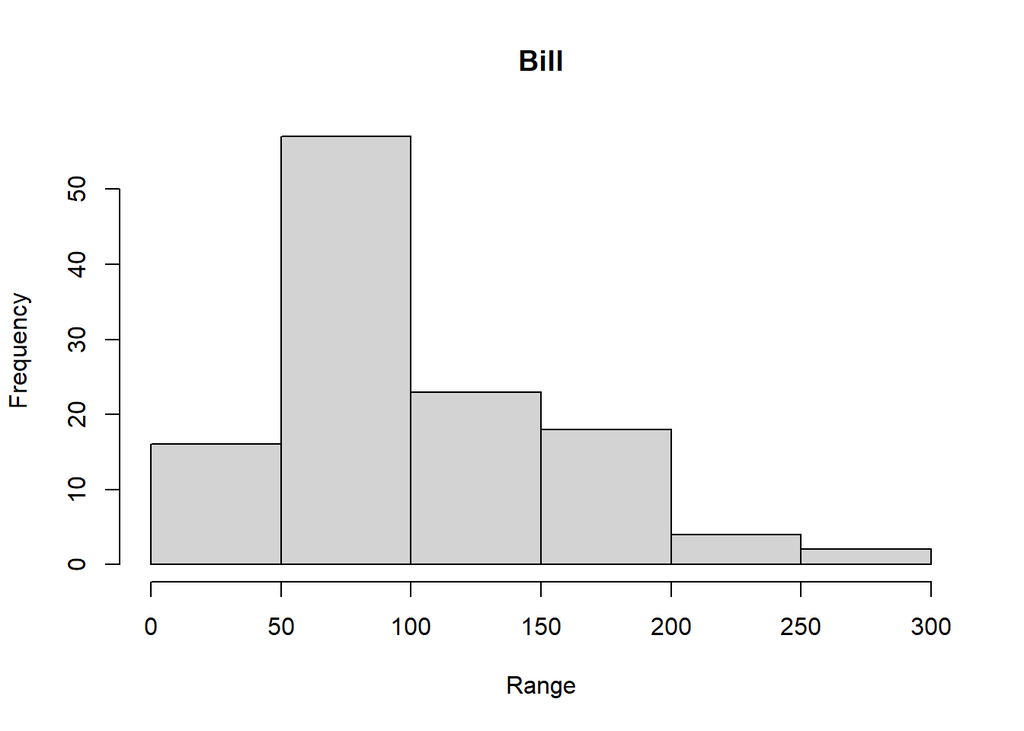

```r
hist(mydata$BILL, main = "Bill", xlab = "Range", ylab="Frequency")
```

And boxplots:

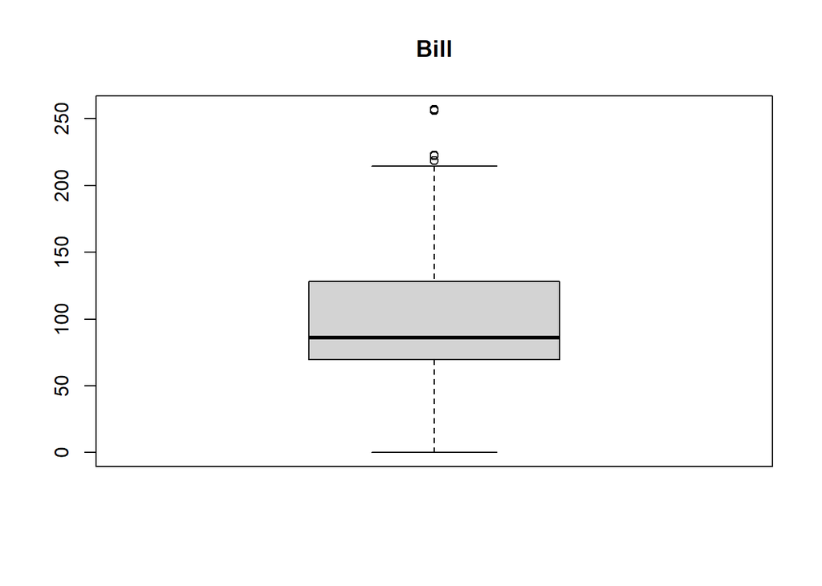

```r
# single boxplot
boxplot(mydata$BILL,main="Bill")
```

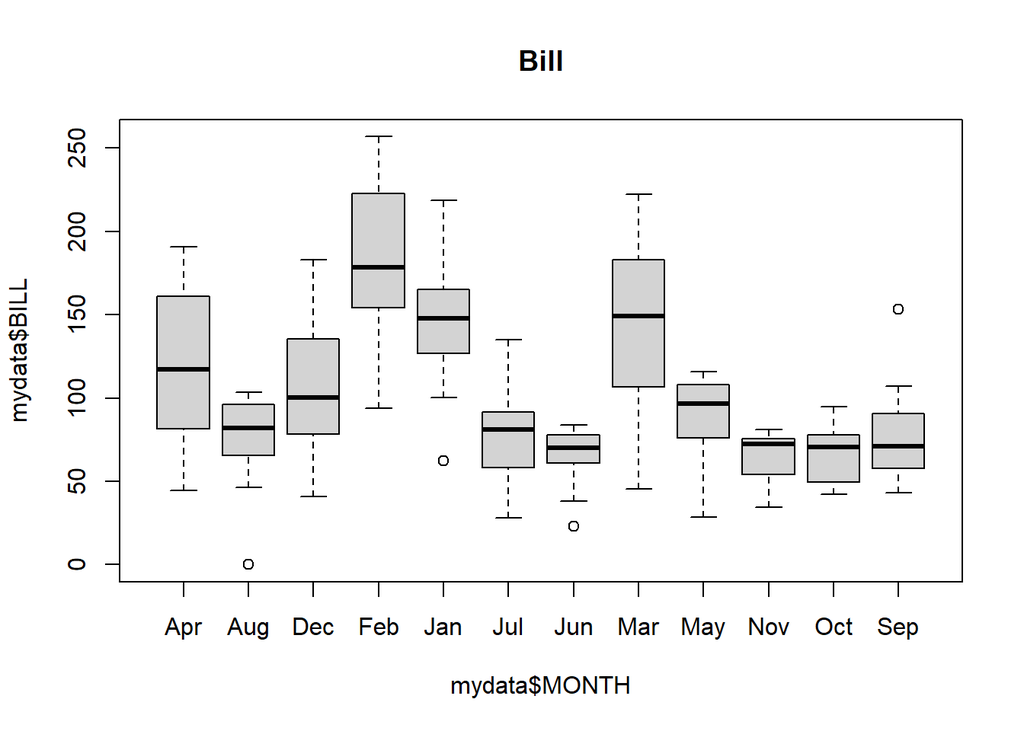

```r
# boxplots side by side
boxplot(mydata$BILL~mydata$MONTH,main="Bill")
```

We can also group several graphs together, so that they are displayed side by side:

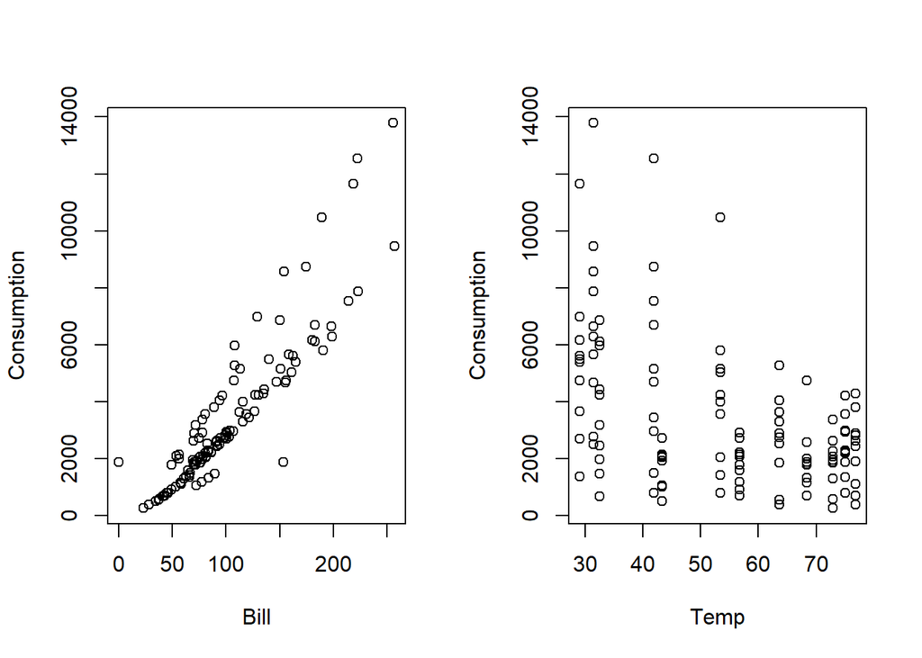

```r
par(mfrow=c(1,2))
plot(mydata$BILL,mydata$CONSUMPTION,xlab="Bill", ylab="Consumption")
plot(mydata$TEMP,mydata$CONSUMPTION,xlab="Temp", ylab="Consumption")
```

```r
par(mfrow=c(1,1))
```

Graphs can be saved in several different forms: pdf, png, jpg, among others. The following code shows how to save the graph in a file called “myplot.jpg”:

```r
jpeg("myplot.jpg")
plot(mydata$BILL,mydata$CONSUMPTION)
dev.off()
```

Several graphs can be saved within the same pdf file (on several pages). Here is an example with 2 figures:

```r
pdf("myplots.pdf")
# First page of the pdf file
plot(mydata$BILL,mydata$CONSUMPTION)
# Second page of the pdf file
plot(mydata$TEMP,mydata$CONSUMPTION)
# Close the file
dev.off()
```

**Exercise**: 1) Create a scatter plot of BILL vs. YEAR for the month of January only. 2) Create a scatter plot of BILL vs. YEAR for the month of June only. 3) Create a scatter plot of BILL vs. YEAR for the month of August only. 4) Create a scatter plot of BILL vs. YEAR for the month of October only. 5) Display the 4 figures on the same page (2 rows 2 columns) and save it in pdf format.

## Final exercise

Using RMarkdown, answer the following regarding the `babyboom` dataset:

1. Produce descriptive statistiscs for the variable `weight`.
2. Produce descriptive statistiscs for the variable `weight`, separately for baby girls and boys.
3. Create 2 boxplots of birthweight as a function of sex.
4. What proportion of baby girls had a weight less than 3 kg? Compare this with the proportion for boys.
5. Display the birthweights of all girls born at least 2 hours after midnight.
6. What is the ID of the baby girl with the lowest weight?
7. Create a scatter plot of weight as a function of the variable `time.midnight`.